# Reproducible Research Course Project 1

Chris Schmidt

08/12/2020

### Step 1 - Read in data

To commence the data analysis, following forking of project from github, it is necessary to load the relevant R packages for transformation and analysis. The data must then be extracted to allow the by unzipping the files and reading them into an R object. In this project I utilise the data.table package, with fread being the function used to read .csv files to an R object.

```r
unzip("./activity.zip", exdir = "./data")
data <- fread(input = "./data//activity.csv")
```

### Step 2 - Histogram of total number of steps taken each day

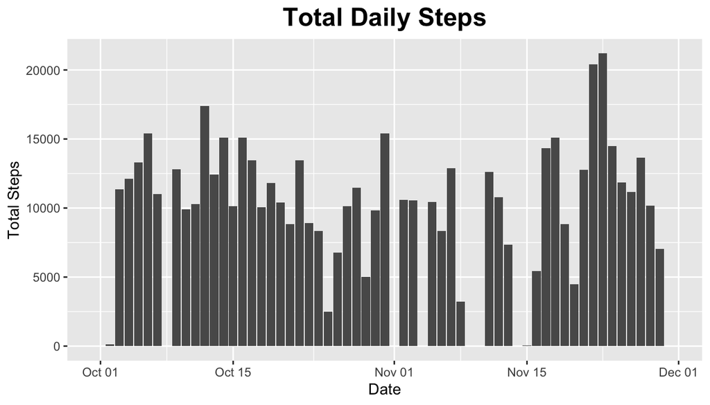

```r
daily_data <- data[, .(`daily_steps` = sum(steps, na.rm = TRUE)), by = date]

plot1 <- ggplot(data = daily_data, mapping = aes(x = date, y = daily_steps))
plot1 + geom_col() +
        ggtitle("Total Daily Steps", ) + xlab("Date") + ylab("Total Steps") +
        theme(plot.title = element_text(face = "bold", size = 18, hjust = 0.5))
```

### Step 3 - Mean and median of number of steps taken each day

```r
daily_data[, .(`Mean Daily Steps` = mean(daily_steps, na.rm = TRUE),
         `Median Daily Steps` = median(daily_steps, na.rm = TRUE))]
```

```
##    Mean Daily Steps Median Daily Steps
## 1:          9354.23              10395
```

### Step 4 - Time series plot of the average number of steps taken

To calculate these results it is necessary to process the data so that it is grouped by time interval, which has been achieved using the `by = x` syntax in the data.table package. This data has then been plotted using the ggplot 2 package and the geom_line() function.

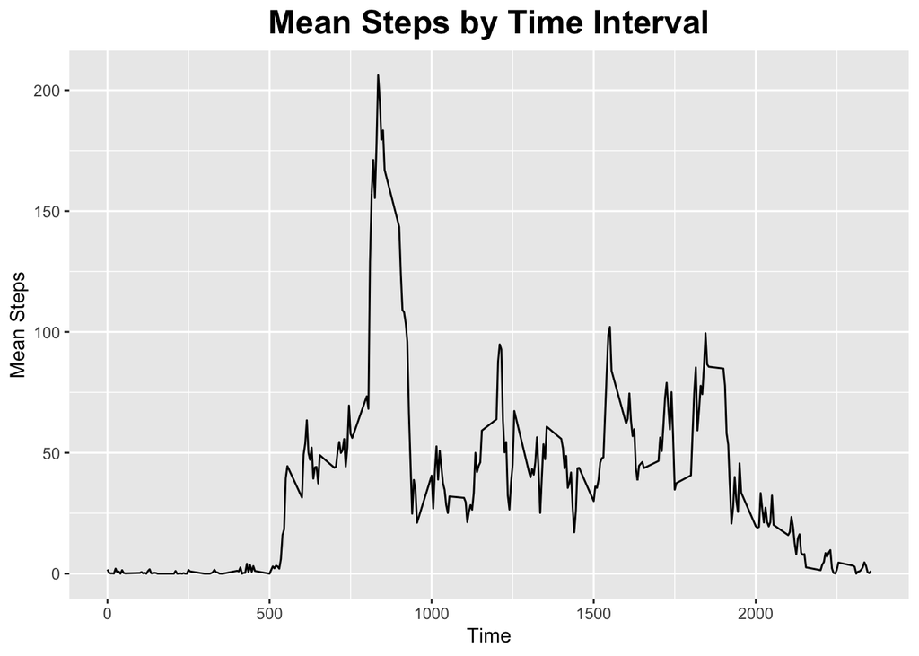

```r
interval_data <- data[, .(`interval_average` = mean(steps, na.rm = TRUE)), by = interval]
plot2 <- ggplot(data = interval_data, mapping = aes(x=interval, y = interval_average))
plot2 + geom_line() +
        ggtitle("Mean Steps by Time Interval") + xlab("Time") + ylab("Mean Steps") +
        theme(plot.title = element_text(face = "bold", size = 18, hjust = 0.5))
```

### Step 5 - Calculate the five minute interval that on average contains the maximum number of steps

This is a simple case of using the which.max function to caculate the row of the interval_data object which has the largest number of average steps. This has then been returned in a statement by using the paste function.

```r
max_interval <- which.max(interval_data[, `interval_average`])
paste ("5 minute interval with most average steps is", interval_data[max_interval, interval])
```

```
## [1] "5 minute interval with most average steps is 835"
```

### Step 6 - Code to describe a strategy for imputing missing data

In order to find the number of rows with NA in the steps column, we simply use the function is.na on the relevant vector and wrap it in the sum function.

```r
nasteps <- sum(is.na(data$steps))
```

This result tells us that there are 2304 NAs in the steps column in the raw dataset.

Missing data (NAs) has been imputed with the intervalvmean, which has already been calculated in the interval_data object, and updating the steps in the data table with this mean value. I note some days also have “0” values for steps, but no attempt is made to impute this data, as legitimate “0” values for steps also appear in the data, and repairing the data in this way is beyond the scope of the assignment.

This has been achieved by joining the interval_data DT to the data DT using data.table’s `on =` syntax. The result has been stored in a new DT imputed_data to clearly identify that it is no longer the raw data which is being shown in the steps column.

The following line of code identifies where an NA value exists in the steps column, an updates it with the (rounded) interval average (as steps is an integer value).

This work has been check by calculating by testing is.na for the imputed_data$steps vector, which returns 0 (ie. TRUE on 0 rows).

```r
imputed_data <- data[interval_data, on = "interval"]
imputed_data[is.na(steps), steps := round(interval_average,0)]
sum(is.na(imputed_data$steps))
```

```
## [1] 0
```

### Step 7 - Histogram of the total number of steps taken each day after missing values imputed

This is completed using the imputed_data object and following the same strategy outlined for the original histogram generated using the raw data only.

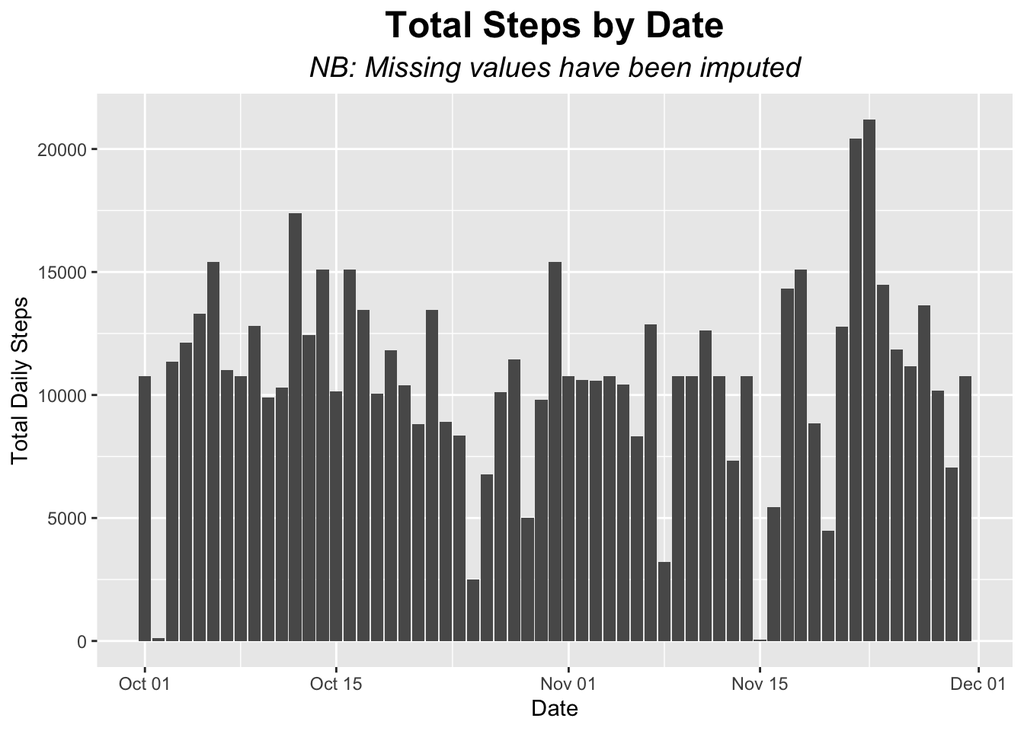

```r
imputed_daily_data <- imputed_data[, .(daily_steps = sum(steps)), by = date]
plot3 <- ggplot(data = imputed_daily_data, mapping = aes(x = date, y = daily_steps))
plot3 + geom_col() +
        labs(title = "Total Steps by Date", subtitle = "NB: Missing values have been imputed") +
        xlab("Date") + ylab("Total Daily Steps") +
        theme(plot.title = element_text(face = "bold", size = 18, hjust = 0.5),
              plot.subtitle = element_text(face = "italic", size = 14, hjust = 0.5))
```

### Step 8 - Comparison of weekday and weekend activity levels

To complete this step the imputed_data object has been transformed by adding a factor variable denoting each observation as belonging to either “Weekday” or “Weekend”. This was achieved through use of an intermediate step of adding a day variable for each observation, derived from the date.

Mean steps for each discrete interval were then calculated and grouped according to whether the observation were of weekdays or weekend days.

Finally this data is plotted using the ggplot package, with geom_line and by constructing separate panels for weekdays and weekend days using the facet_wrap function.

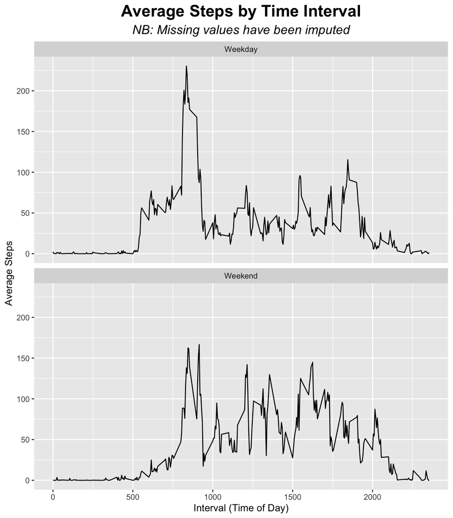

```r
imputed_data[, `:=` (day = weekdays(date), weekday_flag = as.factor("Weekday"))]
imputed_data[day %in% c("Saturday", "Sunday"), weekday_flag := as.factor("Weekend")]
imputed_interval_data <- imputed_data[, .(interval_average = mean(steps)), by = .(interval, weekday_flag)]
plot4 <- ggplot(data = imputed_interval_data, mapping = aes(x=interval, y = interval_average))
plot4 + geom_line() + facet_wrap(.~weekday_flag, nrow = 2) +
        labs(title = "Average Steps by Time Interval", subtitle = "NB: Missing values have been imputed") +
        xlab("Interval (Time of Day)") + ylab("Average Steps") +
        theme(plot.title = element_text(face = "bold", size = 18, hjust = 0.5),
              plot.subtitle = element_text(face = "italic", size = 14, hjust = 0.5))
```